# Amino Acid distribution

The amino acid frequency and ratio in all known proteins w/ and w/o TRs compared with the disorder propensity.

March, 2019

# Housekeeping

```
##          used (Mb) gc trigger (Mb) max used (Mb)
## Ncells 459565 24.6     999217 53.4   627651 33.6
## Vcells 898268  6.9    8388608 64.0  1752011 13.4
```

# Amino Acid Frequency Determination

aa-freq determination:

```r
if(getAAfreq){

  ## Count all AAs in all TRs
  aa_freq <- mclapply(tr_all_sp$MSA,
                      function(i){alphabetFrequency(AAString(i))},
                      mc.cores = numcores)
  aa_freq <-  Reduce(`+`, aa_freq)

  dfTR  <- as.data.frame(aa_freq)
  dfTR$aa <- rownames(dfTR)
  # Remove NAs (*,-,.,+)
  dfTR <- subset(dfTR, !(dfTR$aa %in% aa_ignore)) #TODO add
  # Calculate aa composition ratio in TR
  for (i in 1:nrow(dfTR)){
    dfTR$aa_ratio_tr[i] <- round(dfTR$aa_freq[i]/sum(dfTR$aa_freq), 3)
  }
  colnames(dfTR) <- c("aa_freq_tr", "aa", "aa_ratio_tr")


  ## Count all AAs in all swissprots
  # Read gzip-compressed FASTA file:
  aa_SP <- readAAStringSet("/home/matteo/polybox/MSc_ACLS/swissrepeat/data/uniprot_sprot.fasta.gz")
  # Count all AA in each protein
  dfSP <- mclapply(aa_SP,
                   alphabetFrequency,
                   mc.cores = numcores) # NOTE: Takes few minutes
  # sum AA frequency over all proteins
  dfSP <- Reduce(`+`, dfSP)

  dfSP  <- as.data.frame(dfSP)
  dfSP$aa <- rownames(dfSP)
  colnames(dfSP) <- c("aa_freq_sp", "aa") # For some reason this is needed here for subset below...
  # Remove NAs (*,-,.,+)
  dfSP <- subset(dfSP, !(dfSP[, 2] %in% aa_ignore))
  # Calculate aa composition ratio in Proteinsequences
  for (i in 1:nrow(dfSP)){
    dfSP[i,3] <- round(dfSP[i, 1]/sum(dfSP[1]), 3)
  }
  colnames(dfSP) <- c("aa_freq_sp", "aa", "aa_ratio_sp")
  # Check to aa composition given in statistics from Swissprot proteins (https://web.expasy.org/docs/relnotes/relstat.html)
  # dfSP$aa_ratio_sp_stats <- c(8.25, 5.53, 4.05, 5.46, 1.38, 3.93, 6.73, 7.07, 2.27, 5.92, 9.65, 5.81, 2.41, 3.86, 4.73, 6.62, 5.35, 1.09, 2.92, 6.86, NA, NA, 0, 0, 0)/100

  ## Count all AAs in all Swissprot w/o TRs
  # select all AAs w/o TRs
  aa_SP <- as.data.frame(aa_SP)
  temp <- mclapply(row.names(aa_SP),
                   function(i){
                     strsplit(i, split = "|", fixed = TRUE)})
  temp <- unlist(temp)
  registerDoParallel(numcores)
  aa_SP$ID <- foreach(i = seq(from = 2, to = length(temp), by=3),
                      .combine = rbind) %dopar% {
                        temp[i]
                      }
  stopImplicitCluster()

  dfnegSP <- aa_SP[which(aa_SP$ID %!in% tr_all$ID),]

  # Count all AA in each protein
  dfnegSP <- mclapply(dfnegSP$x,
                      function(i){alphabetFrequency(AAString(i))},
                      mc.cores = numcores)
  # sum AA frequency over all proteins
  dfnegSP <- Reduce(`+`, dfnegSP)

  dfnegSP  <- as.data.frame(dfnegSP)
  dfnegSP$aa <- rownames(dfnegSP)
  colnames(dfnegSP) <- c("aa_freq_sp", "aa") # For some reason this is needed here for subset below...
  # Remove NAs (*,-,.,+)
  dfnegSP <- subset(dfnegSP, !(dfnegSP[,2] %in% aa_ignore))
  # Calculate aa composition ratio in Proteinsequences
  for (i in 1:nrow(dfnegSP)){
    dfnegSP[i,3] <- round(dfnegSP[i, 1]/sum(dfnegSP[1]), 3)
  }
  colnames(dfnegSP) <- c("aa_freq_negsp", "aa", "aa_ratio_negsp")


  ## Combine all data toghether
  # Combine dfSP and dfTR (AA frequency distribution within TRs)
  df <- merge(x = dfSP, y=dfTR, by= "aa")
  # add dfnegSP
  df <- cbind(df, dfnegSP$aa_freq_negsp, dfnegSP$aa_ratio_negsp)
  colnames(df) <- c( "aa", "aa_freq_sp", "aa_ratio_sp", "aa_freq_tr", "aa_ratio_tr", "aa_freq_negsp", "aa_ratio_negsp")
  # Sort AA according to their disorder promoting potential
  df <- df[match(aa_order_promoting_to_disorder_promoting, df$aa),]

  # save for later use
  write.csv(df, file = paste0(local_base_path, "/data/aa_count.csv"), row.names = df$aa)
}

# load AA counts
df <- read.csv(paste0(local_base_path, "/data/aa_count.csv"), header = TRUE)
df <- df[,-1]
# Encode the order of the AA as increasing factor
df$aafac <- seq(1, length(df$aa))
# Add the disorder propensity from Uversky paper
df$disorderpropensity <- c(0.00, 0.004, 0.090, 0.113, 0.117, 0.195, 0.259, 0.263, 0.285, 0.291, 0.394, 0.401, 0.407, 0.437, 0.450, 0.588,0.665,0.713, 0.781,1.000, NA, NA, NA, NA, NA)
# calculate disorder propensity manually
#TODO

## from wide to long format
dfRatio.long <- df %>%
  gather(ratio_source, aa_ratio, -c("aa", "aa_freq_sp", "aa_freq_tr", "aa_freq_negsp", "aafac", "disorderpropensity"))
# change labelling
dfRatio.long$ratio_source <- replace(dfRatio.long$ratio_source, dfRatio.long$ratio_source =="aa_ratio_sp", "all Swissprots")
dfRatio.long$ratio_source <- replace(dfRatio.long$ratio_source, dfRatio.long$ratio_source =="aa_ratio_tr", "only TRs")
dfRatio.long$ratio_source <- replace(dfRatio.long$ratio_source, dfRatio.long$ratio_source =="aa_ratio_negsp", "all Swissprots w/o TRs")
dfRatio.long <- dfRatio.long[,-c(2:4)]

dfFreq.long <- df %>%
  gather(freq_source, aa_freq, -c("aa", "aa_ratio_sp", "aa_ratio_tr", "aa_ratio_negsp", "aafac", "disorderpropensity"))
# change labelling
dfFreq.long$freq_source <- replace(dfFreq.long$freq_source, dfFreq.long$freq_source =="aa_freq_sp", "all Swissprots")
dfFreq.long$freq_source <- replace(dfFreq.long$freq_source, dfFreq.long$freq_source =="aa_freq_tr", "only TRs")
dfFreq.long$freq_source <- replace(dfFreq.long$freq_source, dfFreq.long$freq_source =="aa_freq_negsp", "all Swissprots w/o TRs")
dfFreq.long <- dfFreq.long[, -c(2:4)]
```

# AA Frequency

### Frequency plots: Explicit number of AA occuring in the specific region (either TR or the whole protein)

AA frequency in TR region vs. disorder propensity

```r
model.lm.tr <- lm(aa_freq_tr ~ disorderpropensity, data = df)
summary(model.lm.tr)
```

```
##
## Call:
## lm(formula = aa_freq_tr ~ disorderpropensity, data = df)
##
## Residuals:
##     Min      1Q  Median      3Q     Max
## -531300 -248999  -81526  184301 1017356
##
## Coefficients:
##                    Estimate Std. Error t value Pr(>|t|)
## (Intercept)          516053     151851   3.398  0.00320 **
## disorderpropensity  1066640     333108   3.202  0.00494 **
## ---
## Signif. codes:  0 '***' 0.001 '**' 0.01 '*' 0.05 '.' 0.1 ' ' 1
##
## Residual standard error: 391100 on 18 degrees of freedom
##   (5 observations deleted due to missingness)
## Multiple R-squared:  0.3629, Adjusted R-squared:  0.3275
## F-statistic: 10.25 on 1 and 18 DF,  p-value: 0.00494
```

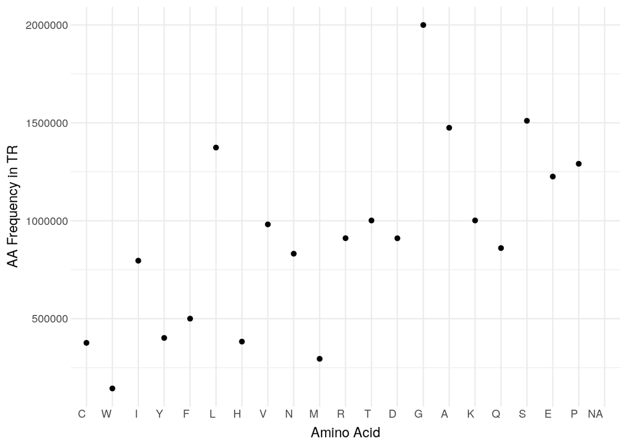

```r
# labelling good, geom_smooth bad
p1 <- ggplot(df)+
  geom_point(aes(x = as.factor(disorderpropensity), y = aa_freq_tr))+
  scale_x_discrete(labels = as.character(df$aa),
                   breaks = df$disorderpropensity)+
  # stat_smooth(method = "lm",
  #             data = df, aes(x = disorderpropensity, y = aa_freq_tr),
  #             se = F)+ # TODO: fix appearance of stat_smooth or geom_smooth
  labs(x ="Amino Acid",
       y = "AA Frequency in TR")+
  theme_minimal()
p1 <- beautifier(p1)+
  theme(axis.text.x = element_text(angle = 0, hjust = 1.1))
p1
```

```r
#####
# # labelling bad, geom_smooth good
# p1 <- ggplot(df, aes(x = disorderpropensity, y = aa_freq_tr))+
#   geom_point()+
#   scale_x_discrete(labels = as.character(df$aa),
#                      breaks = df$disorderpropensity)+
#   stat_smooth(method = "lm")+ # TODO: fix appearance of stat_smooth or geom_smooth
#   labs(x ="Amino Acid",
#        y = "AA Frequency in TR")+
#   theme_minimal()
# p1 <- beautifier(p1)+
#   theme(axis.text.x = element_text(angle = 0, hjust = 1.1))
# p1
#
# # other approach with abline
# p1 <- ggplot(df, aes(x = disorderpropensity, y = aa_freq_tr))+
#   geom_point()+
#   scale_x_continuous(labels = as.character(df$aa),
#                      breaks = df$disorderpropensity)+
#   geom_abline(intercept = coefficients(model.lm.tr)[1], slope = coefficients(model.lm.tr)[2])+
#   labs(x ="Amino Acid",
#        y = "AA Frequency in TR")+
#   theme_minimal()
# p1 <- beautifier(p1)+
#   theme(axis.text.x = element_text(angle = 0, hjust = 1.1, vjust = 0.5))
# p1
#
# # other approach with geom_stats
# p1 <- ggplot(df, aes(x = as.factor(disorderpropensity), y = aa_freq_tr))+
#   geom_point()+
#   scale_x_discrete(labels = as.character(df$aa),
#                      breaks = df$disorderpropensity)+
#   stat_smooth(method = "lm", aes(group = "C"))+
#   labs(x ="Amino Acid",
#        y = "AA Frequency in TR")+
#   theme_minimal()
# p1 <- beautifier(p1)+
#   theme(axis.text.x = element_text(angle = 0, hjust = 1.1, vjust = 0.5))
# p1
#####
if( save) {
  ggsave(paste0(pathImages, "AA_frequencyTR_scatter", figureFormat), width=12, height=8, dpi = 300)
}
```

AA frequency in all Swissprots vs. disorder propensity

```r
model.lm.sp <- lm(aa_freq_sp ~ disorderpropensity, data = df)
summary(model.lm.sp)
```

```
##
## Call:
## lm(formula = aa_freq_sp ~ disorderpropensity, data = df)
##
## Residuals:
##      Min       1Q   Median       3Q      Max
## -5525037 -4102688   411481  1756767 10469475
##
## Coefficients:
##                    Estimate Std. Error t value Pr(>|t|)
## (Intercept)         7705777    1690589   4.558 0.000244 ***
## disorderpropensity  6276827    3708551   1.693 0.107782
## ---
## Signif. codes:  0 '***' 0.001 '**' 0.01 '*' 0.05 '.' 0.1 ' ' 1
##
## Residual standard error: 4355000 on 18 degrees of freedom
##   (5 observations deleted due to missingness)
## Multiple R-squared:  0.1373, Adjusted R-squared:  0.08937
## F-statistic: 2.865 on 1 and 18 DF,  p-value: 0.1078
```

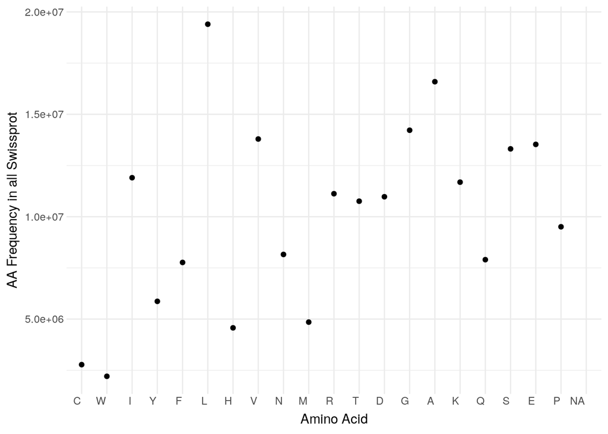

```r
# labelling good, geom_smooth bad
p2 <- ggplot(df)+
  geom_point(aes(x = as.factor(disorderpropensity), y = aa_freq_sp))+
  scale_x_discrete(labels = as.character(df$aa),
                   breaks = df$disorderpropensity)+
  # stat_smooth(method = "lm",
  #             data = df, aes(x = disorderpropensity, y = aa_freq_sp),
  #             se = F)+ # TODO: fix appearance of stat_smooth or geom_smooth
  labs(x ="Amino Acid",
       y = "AA Frequency in all Swissprot")+
  theme_minimal()
p2 <- beautifier(p2)+
  theme(axis.text.x = element_text(angle = 0, hjust = 1.1))
p2
```

```r
#####
# # labelling bad, geom_smooth good
# p2 <- ggplot(df, aes(x = disorderpropensity, y = aa_freq_sp))+
#   geom_point()+
#   scale_x_discrete(labels = as.character(df$aa),
#                      breaks = df$disorderpropensity)+
#   stat_smooth(method = "lm")+ # TODO: fix appearance of stat_smooth or geom_smooth
#   labs(x ="Amino Acid",
#        y = "AA Frequency in all Swissprot")+
#   theme_minimal()
# p2 <- beautifier(p2)+
#   theme(axis.text.x = element_text(angle = 0, hjust = 1.1))
# p2
######

if( save) {
  ggsave(paste0(pathImages, "AA_frequencySP_scatter", figureFormat), width=12, height=8, dpi = 300)
}
```

AA frequency in all Swissprot w/o TRs vs. disorder propensity

```r
model.lm.negsp <- lm(aa_freq_negsp ~ disorderpropensity, data = df)
summary(model.lm.negsp)
```

```
##
## Call:
## lm(formula = aa_freq_negsp ~ disorderpropensity, data = df)
##
## Residuals:
##      Min       1Q   Median       3Q      Max
## -4886694 -1315663   543950  1476435  4806841
##
## Coefficients:
##                    Estimate Std. Error t value Pr(>|t|)
## (Intercept)         4904966     987868   4.965   0.0001 ***
## disorderpropensity  -161696    2167032  -0.075   0.9413
## ---
## Signif. codes:  0 '***' 0.001 '**' 0.01 '*' 0.05 '.' 0.1 ' ' 1
##
## Residual standard error: 2545000 on 18 degrees of freedom
##   (5 observations deleted due to missingness)
## Multiple R-squared:  0.0003092,  Adjusted R-squared:  -0.05523
## F-statistic: 0.005568 on 1 and 18 DF,  p-value: 0.9413
```

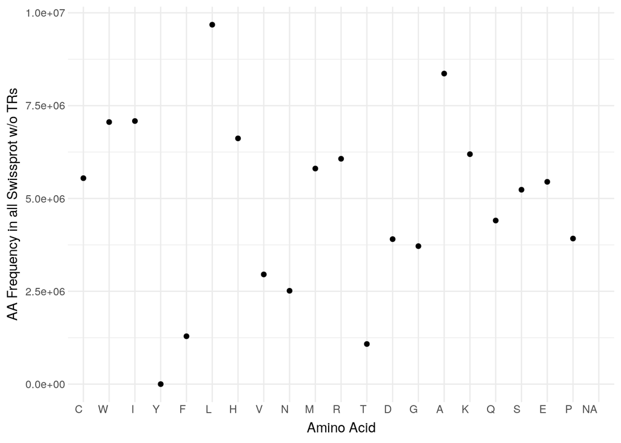

```r
# labelling good, geom_smooth bad
p3 <- ggplot(df)+
  geom_point(aes(x = as.factor(disorderpropensity), y = aa_freq_negsp))+
  scale_x_discrete(labels = as.character(df$aa),
                   breaks = df$disorderpropensity)+
  # stat_smooth(method = "lm",
  #             data = df, aes(x = disorderpropensity, y = aa_freq_negsp),
  #             se = F)+ # TODO: fix appearance of stat_smooth or geom_smooth
  labs(x ="Amino Acid",
       y = "AA Frequency in all Swissprot w/o TRs")+
  theme_minimal()
p3 <- beautifier(p3)+
  theme(axis.text.x = element_text(angle = 0, hjust = 1.1))
p3
```

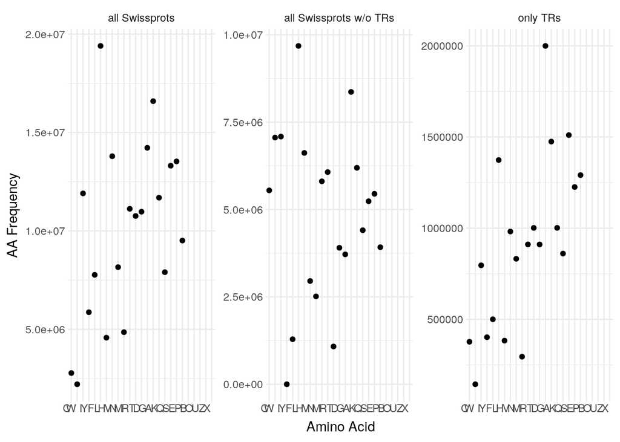

```r
#####
# # labelling bad, geom_smooth good
# p3 <- ggplot(df, aes(x = disorderpropensity, y = aa_freq_negsp))+
#   geom_point()+
#   scale_x_discrete(labels = as.character(df$aa),
#                      breaks = df$disorderpropensity)+
#   stat_smooth(method = "lm")+ # TODO: fix appearance of stat_smooth or geom_smooth
#   labs(x ="Amino Acid",
#        y = "AA Frequency in all Swissprot w/o TRs")+
#   theme_minimal()
# p3 <- beautifier(p3)+
#   theme(axis.text.x = element_text(angle = 0, hjust = 1.1))
# p3
#####

if( save) {
  ggsave(paste0(pathImages, "AA_frequencynegSP_scatter", figureFormat), width=12, height=8, dpi = 300)
}
model <- lm(dfFreq.long$aa_freq~dfFreq.long$aafac, dfFreq.long[which(dfFreq.long$aa_freq > 10000),])
p <- ggplot(dfFreq.long, aes(x = dfFreq.long$aa, y = dfFreq.long$aa_freq))+
  facet_wrap(~freq_source, scales = "free")+
  geom_point()+
  scale_x_discrete(limits = aa_order_promoting_to_disorder_promoting)+
  # geom_abline(intercept = coefficients(model)[1], slope = coefficients(model)[2])+
  # stat_smooth(method = "lm", aes(group = dfFreq.long$freq_source))+ # TODO: fix appearance of stat_smooth or geom_smooth
  labs(x ="Amino Acid",
       y = "AA Frequency")+
  theme_minimal()
p <- beautifier(p)+
  theme(axis.text.x = element_text(angle = 0, hjust = 1.1))+
  scale_color_manual(values = cols1,
                     name  ="AA sources",
                     breaks=c("aa_ratio_sp","aa_ratio_tr"),
                     labels=c("all Swissprots", "only TRs")) +
  scale_fill_manual(values = cols1,
                    name  ="AA sources",
                    breaks=c("aa_ratio_sp","aa_ratio_tr"),
                    labels=c("all Swissprots", "only TRs"))
p
```

```r
if( save) {
  ggsave(paste0(pathImages, "AA_frequency_facet", figureFormat), width=12, height=8, dpi = 300)
}
#####
# # model <- lm(dfFreq.long$aa_freq~dfFreq.long$aa, dfFreq.long)
# # model <- lm(dfFreq.long$aa_freq~dfFreq.long$aafac, dfFreq.long)
# model <- lm(df$aa_freq_tr ~ df$disorderpropensity, data = df) # This works for "all swissprots", however not for the others. Check in single plots first!
# summary(lm(aa_freq_tr ~ disorderpropensity, data = df))
# p <- ggplot(dfFreq.long, aes(x = dfFreq.long$aa, y = dfFreq.long$aa_freq))+
#   facet_wrap(~freq_source, scales = "free")+
#   geom_point()+
#   scale_x_discrete(limits = aa_order_promoting_to_disorder_promoting)+
#   # geom_abline(intercept = coefficients(model)[1], slope = coefficients(model)[2])+
#   # stat_smooth(method = "lm", aes(group = dfFreq.long$freq_source))+ # TODO: fix appearance of stat_smooth or geom_smooth
#   labs(x ="Amino Acid",
#        y = "AA Frequency")+
#   theme_minimal()
# p <- beautifier(p)+
#   theme(axis.text.x = element_text(angle = 0, hjust = 1.1))+
#   scale_color_manual(values = cols1,
#                       name  ="AA sources",
#                       breaks=c("aa_ratio_sp","aa_ratio_tr"),
#                       labels=c("all Swissprots", "only TRs")) +
#   scale_fill_manual(values = cols1,
#                     name  ="AA sources",
#                       breaks=c("aa_ratio_sp","aa_ratio_tr"),
#                       labels=c("all Swissprots", "only TRs"))
# p
```

The frequency of each AA (ordered by their decreasing order-promoting potential (top: ordered, bottom: disordered)) from all TR containing proteins. Disorder promoting residues occur more frequently in TR than oder promoting.

From Uversky2013: In fact, in comparison with ordered proteins, IDPs/IDPRs are characterized by noticeable biases in their amino acid compositions, containing less of so-called “order-promoting” residues (cysteine, tryptophan, isoleucine, tyrosine, phenylalanine, leucine, histidine, valine, asparagines and methionine, which are mostly hydrophobic residues which are commonly found within the hydrophobic cores of foldable proteins) and more of “disorder-promoting” residues (lysine, glutamine, serine, glutamic acid and proline, which are mostly polar and charged residues, which are typically located at the surface of foldable proteins)

# AA Ratio

```r
model.lm.tr.ratio <- lm(aa_ratio_tr ~ disorderpropensity, data = df)
summary(model.lm.tr.ratio)
```

```
##
## Call:
## lm(formula = aa_ratio_tr ~ disorderpropensity, data = df)
##
## Residuals:
##       Min        1Q    Median        3Q       Max
## -0.029329 -0.013636 -0.004533  0.010334  0.055140
##
## Coefficients:
##                    Estimate Std. Error t value Pr(>|t|)
## (Intercept)        0.028327   0.008296   3.414  0.00309 **
## disorderpropensity 0.058428   0.018200   3.210  0.00485 **
## ---
## Signif. codes:  0 '***' 0.001 '**' 0.01 '*' 0.05 '.' 0.1 ' ' 1
##
## Residual standard error: 0.02137 on 18 degrees of freedom
##   (5 observations deleted due to missingness)
## Multiple R-squared:  0.3641, Adjusted R-squared:  0.3288
## F-statistic: 10.31 on 1 and 18 DF,  p-value: 0.00485
```

```r
model.lm.sp.ratio <- lm(aa_ratio_sp ~ disorderpropensity, data = df)
summary(model.lm.sp.ratio)
```

```
##
## Call:
## lm(formula = aa_ratio_sp ~ disorderpropensity, data = df)
##
## Residuals:
##       Min        1Q    Median        3Q       Max
## -0.027722 -0.020607  0.002206  0.008528  0.052409
##
## Coefficients:
##                    Estimate Std. Error t value Pr(>|t|)
## (Intercept)        0.038599   0.008461   4.562 0.000241 ***
## disorderpropensity 0.030728   0.018559   1.656 0.115120
## ---
## Signif. codes:  0 '***' 0.001 '**' 0.01 '*' 0.05 '.' 0.1 ' ' 1
##
## Residual standard error: 0.02179 on 18 degrees of freedom
##   (5 observations deleted due to missingness)
## Multiple R-squared:  0.1322, Adjusted R-squared:  0.08395
## F-statistic: 2.741 on 1 and 18 DF,  p-value: 0.1151
```

```r
model.lm.negsp.ratio <- lm(aa_ratio_negsp ~ disorderpropensity, data = df)
summary(model.lm.negsp.ratio)
```

```
##
## Call:
## lm(formula = aa_ratio_negsp ~ disorderpropensity, data = df)
##
## Residuals:
##       Min        1Q    Median        3Q       Max
## -0.049199 -0.013518  0.005675  0.014654  0.048927
##
## Coefficients:
##                     Estimate Std. Error t value Pr(>|t|)
## (Intercept)         0.049372   0.009963   4.955 0.000102 ***
## disorderpropensity -0.001536   0.021856  -0.070 0.944761
## ---
## Signif. codes:  0 '***' 0.001 '**' 0.01 '*' 0.05 '.' 0.1 ' ' 1
##
## Residual standard error: 0.02566 on 18 degrees of freedom
##   (5 observations deleted due to missingness)
## Multiple R-squared:  0.0002742,  Adjusted R-squared:  -0.05527
## F-statistic: 0.004937 on 1 and 18 DF,  p-value: 0.9448
```

### Ratio plots: Ratio of #AAx/sum(of all AA in the protein or TR)

AA ratio in TR region vs. disorder propensity

```r
model.lm.tr <- lm(aa_ratio_tr ~ disorderpropensity, data = df)
summary(model.lm.tr)
```

```
##
## Call:
## lm(formula = aa_ratio_tr ~ disorderpropensity, data = df)
##
## Residuals:
##       Min        1Q    Median        3Q       Max
## -0.029329 -0.013636 -0.004533  0.010334  0.055140
##
## Coefficients:
##                    Estimate Std. Error t value Pr(>|t|)
## (Intercept)        0.028327   0.008296   3.414  0.00309 **
## disorderpropensity 0.058428   0.018200   3.210  0.00485 **
## ---
## Signif. codes:  0 '***' 0.001 '**' 0.01 '*' 0.05 '.' 0.1 ' ' 1
##
## Residual standard error: 0.02137 on 18 degrees of freedom
##   (5 observations deleted due to missingness)
## Multiple R-squared:  0.3641, Adjusted R-squared:  0.3288
## F-statistic: 10.31 on 1 and 18 DF,  p-value: 0.00485
```

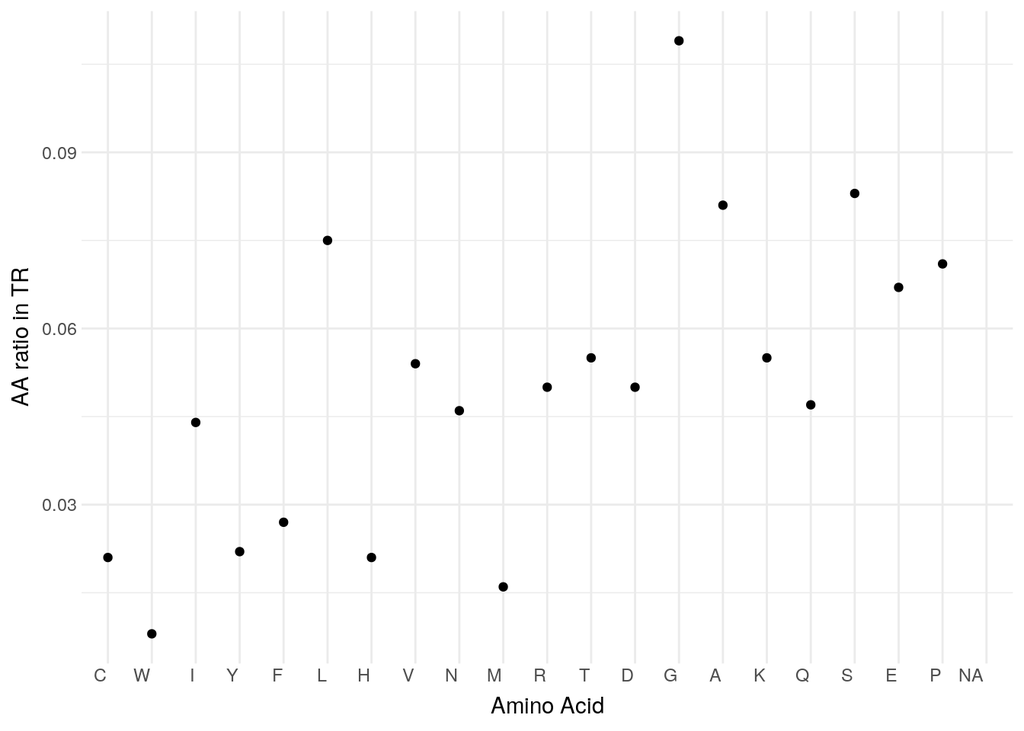

```r
# labelling good, geom_smooth bad
p1 <- ggplot(df)+
  geom_point(aes(x = as.factor(disorderpropensity), y = aa_ratio_tr))+
  scale_x_discrete(labels = as.character(df$aa),
                   breaks = df$disorderpropensity)+
  # stat_smooth(method = "lm",
  #             data = df, aes(x = disorderpropensity, y = aa_ratio_tr),
  #             se = F)+ # TODO: fix appearance of stat_smooth or geom_smooth
  labs(x ="Amino Acid",
       y = "AA ratio in TR")+
  theme_minimal()
p1 <- beautifier(p1)+
  theme(axis.text.x = element_text(angle = 0, hjust = 1.1))
p1
```

```r
if( save) {
  ggsave(paste0(pathImages, "AA_ratioTR_scatter", figureFormat), width=12, height=8, dpi = 300)
}
```

AA ratio in all Swissprots vs. disorder propensity

```r
model.lm.sp <- lm(aa_ratio_sp ~ disorderpropensity, data = df)
summary(model.lm.sp)
```

```
##
## Call:
## lm(formula = aa_ratio_sp ~ disorderpropensity, data = df)
##
## Residuals:
##       Min        1Q    Median        3Q       Max
## -0.027722 -0.020607  0.002206  0.008528  0.052409
##
## Coefficients:
##                    Estimate Std. Error t value Pr(>|t|)
## (Intercept)        0.038599   0.008461   4.562 0.000241 ***
## disorderpropensity 0.030728   0.018559   1.656 0.115120
## ---
## Signif. codes:  0 '***' 0.001 '**' 0.01 '*' 0.05 '.' 0.1 ' ' 1
##
## Residual standard error: 0.02179 on 18 degrees of freedom
##   (5 observations deleted due to missingness)
## Multiple R-squared:  0.1322, Adjusted R-squared:  0.08395
## F-statistic: 2.741 on 1 and 18 DF,  p-value: 0.1151
```

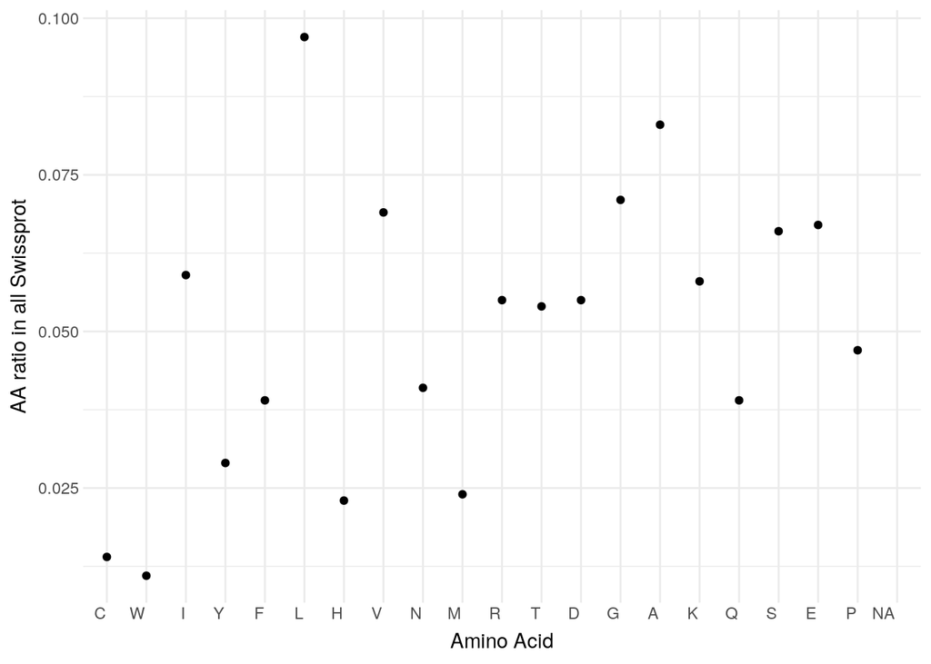

```r
# labelling good, geom_smooth bad
p2 <- ggplot(df)+
  geom_point(aes(x = as.factor(disorderpropensity), y = aa_ratio_sp))+
  scale_x_discrete(labels = as.character(df$aa),
                   breaks = df$disorderpropensity)+
  # stat_smooth(method = "lm",
  #             data = df, aes(x = disorderpropensity, y = aa_ratio_sp),
  #             se = F)+ # TODO: fix appearance of stat_smooth or geom_smooth
  labs(x ="Amino Acid",
       y = "AA ratio in all Swissprot")+
  theme_minimal()
p2 <- beautifier(p2)+
  theme(axis.text.x = element_text(angle = 0, hjust = 1.1))
p2
```

```r
if( save) {
  ggsave(paste0(pathImages, "AA_ratioSP_scatter", figureFormat), width=12, height=8, dpi = 300)
}
```

AA ratio in all Swissprot w/o TRs vs. disorder propensity

```r
model.lm.negsp <- lm(aa_ratio_negsp ~ disorderpropensity, data = df)
summary(model.lm.negsp)
```

```
##
## Call:
## lm(formula = aa_ratio_negsp ~ disorderpropensity, data = df)
##
## Residuals:
##       Min        1Q    Median        3Q       Max
## -0.049199 -0.013518  0.005675  0.014654  0.048927
##
## Coefficients:
##                     Estimate Std. Error t value Pr(>|t|)
## (Intercept)         0.049372   0.009963   4.955 0.000102 ***
## disorderpropensity -0.001536   0.021856  -0.070 0.944761
## ---
## Signif. codes:  0 '***' 0.001 '**' 0.01 '*' 0.05 '.' 0.1 ' ' 1
##
## Residual standard error: 0.02566 on 18 degrees of freedom
##   (5 observations deleted due to missingness)
## Multiple R-squared:  0.0002742,  Adjusted R-squared:  -0.05527
## F-statistic: 0.004937 on 1 and 18 DF,  p-value: 0.9448
```

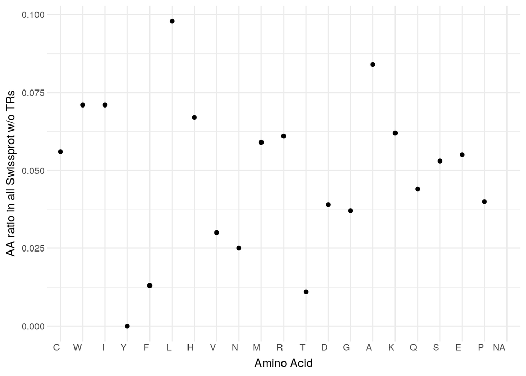

```r
# labelling good, geom_smooth bad
p3 <- ggplot(df)+
  geom_point(aes(x = as.factor(disorderpropensity), y = aa_ratio_negsp))+
  scale_x_discrete(labels = as.character(df$aa),
                   breaks = df$disorderpropensity)+
  # stat_smooth(method = "lm",
  #             data = df, aes(x = disorderpropensity, y = aa_ratio_negsp),
  #             se = F)+ # TODO: fix appearance of stat_smooth or geom_smooth
  labs(x ="Amino Acid",
       y = "AA ratio in all Swissprot w/o TRs")+
  theme_minimal()
p3 <- beautifier(p3)+
  theme(axis.text.x = element_text(angle = 0, hjust = 1.1))
p3
```

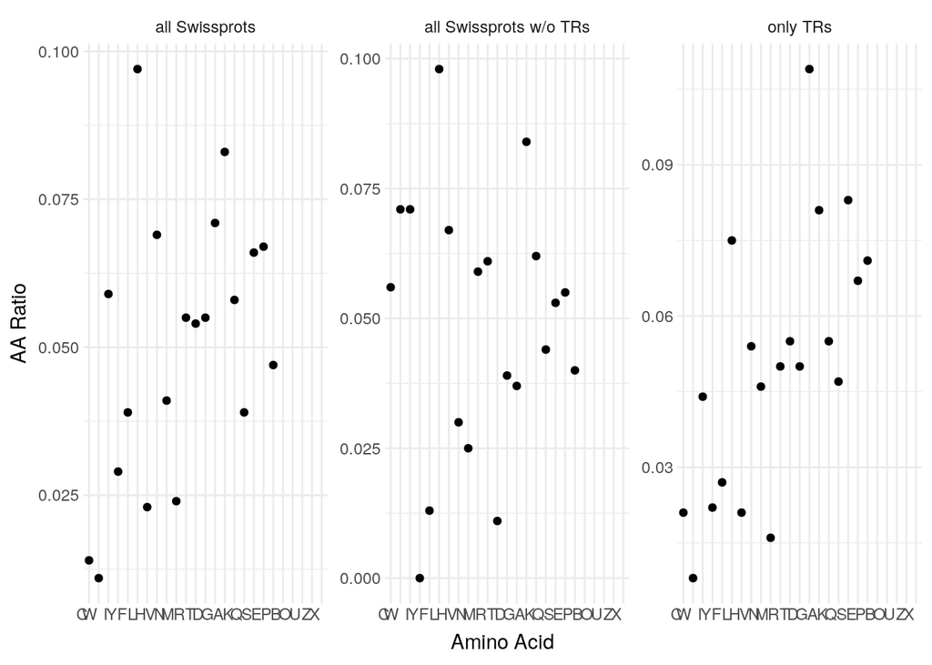

```r
if( save) {
  ggsave(paste0(pathImages, "AA_rationegSP_scatter", figureFormat), width=12, height=8, dpi = 300)
}
model <- lm(dfRatio.long$aa_ratio~dfRatio.long$aafac, dfRatio.long)
p <- ggplot(dfRatio.long, aes(x = dfRatio.long$aa, y = dfRatio.long$aa_ratio))+
  facet_wrap(~ratio_source, scales = "free")+
  geom_point()+
  scale_x_discrete(limits = aa_order_promoting_to_disorder_promoting)+
  # geom_abline(intercept = coefficients(model)[1], slope = coefficients(model)[2])+
  # stat_smooth(method = "lm", aes(group = dfRatio.long$ratio_source))+ # TODO: fix appearance of stat_smooth or geom_smooth
  labs(x ="Amino Acid",
       y = "AA Ratio")+
  theme_minimal()
p <- beautifier(p)+
  theme(axis.text.x = element_text(angle = 0, hjust = 1.1))+
  scale_color_manual(values = cols1,
                     name  ="AA sources",
                     breaks=c("aa_ratio_sp","aa_ratio_tr"),
                     labels=c("all Swissprots", "only TRs")) +
  scale_fill_manual(values = cols1,
                    name  ="AA sources",
                    breaks=c("aa_ratio_sp","aa_ratio_tr"),
                    labels=c("all Swissprots", "only TRs"))
p
```

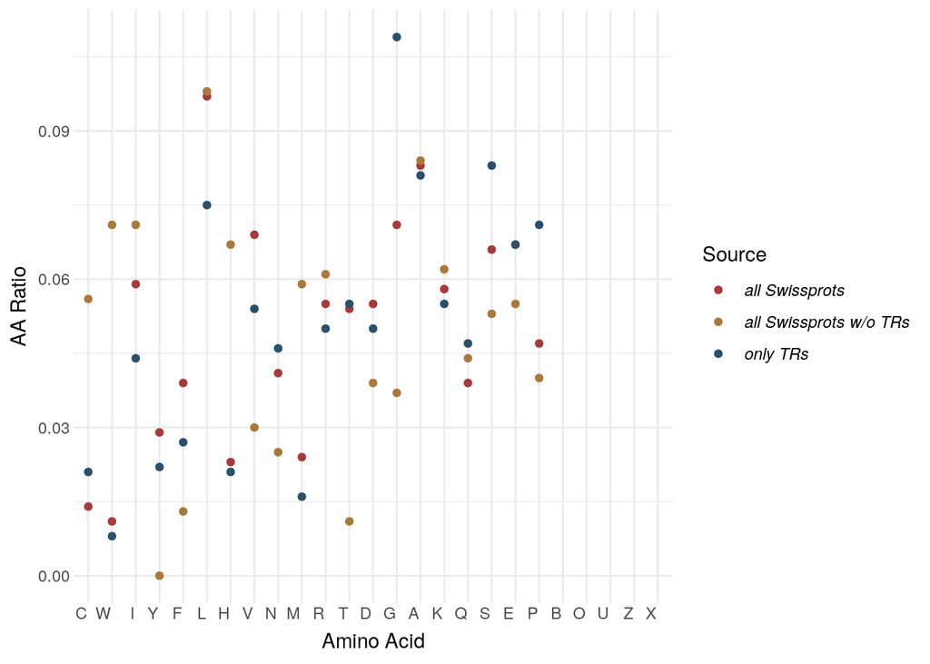

```r
if( save) {
  ggsave(paste0(pathImages, "AA_ratio_facet", figureFormat), width=12, height=8, dpi = 300)
}
p5 <- ggplot(dfRatio.long, aes(x = dfRatio.long$aa, y = dfRatio.long$aa_ratio, color = dfRatio.long$ratio_source))+
  geom_point()+
  scale_x_discrete(limits = aa_order_promoting_to_disorder_promoting)+
  # geom_abline(intercept = coefficients(model)[1], slope = coefficients(model)[2])+
  # stat_smooth(method = "lm", aes(group = dfRatio.long$ratio_source))+ # TODO: fix appearance of stat_smooth or geom_smooth
  labs(x ="Amino Acid",
       y = "AA Ratio")+
  theme_minimal()
p5 <- beautifier(p5)+
  theme(axis.text.x = element_text(angle = 0, hjust = 1.1),
        legend.position = "right")+
  scale_color_manual(values = cols1,
                     name = "Source")
p5
```

```r
if( save) {
  ggsave(paste0(pathImages, "AA_ratio_scatterall", figureFormat), width=12, height=8, dpi = 300)
}
```